Metody uczenia maszynowego 2023/24

# Problemy uczenia maszynowego

```python
# -*- coding: utf-8 -*-

import numpy as np
import pandas as pd

%matplotlib inline
import matplotlib.pyplot as plt
import seaborn as sns
from mpl_toolkits.mplot3d import Axes3D
from matplotlib import cm
from matplotlib.ticker import LinearLocator, FormatStrFormatter
plt.style.use("fivethirtyeight")
sns.set(font_scale=1.5)
# from IPython import display, Markdown, Latex
from IPython.display import display, Image, Markdown, Latex, YouTubeVideo
```

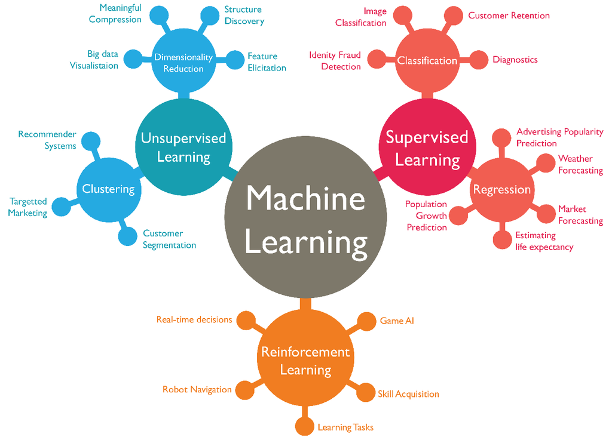

```python
Image(data="ml_figures/Wstep_ml_graph.png", width=800)
```

# Procesy uczenia

## nadzorowane

- dane $$\{(x_i,y_i)\}$$ gdzie $y_i$ jest **poprawną odpowiedzią (true)**
  - $y_i$ jest wartością w $\mathbb{R}$ lub etykietą
- algorytm modyfikuje parametry modelu w kolejnych krokach
- algorytm porównuje odpowiedź modelu z poprawną uzyskując **błąd**
- błąd wpływa na modyfikację parametrów tak by minimalizować całkowity błąd

## nienadzorowane

- dane w postaci $$\{x_i\}$$ **bez** prawidłowej wartości
- algorytm wyszukuje **statystyczne** zależności
- efektem może być podział na skupiska (klastrowanie)
  - ekspert może określić klasy dla skupisk
- może być wstępem do uczenia nadzorowanego
  - dane **etykietowane** są bardzo kosztowne
  - należy wykorzystać wszystkie dostępne -- potrzebujemy by danych było co najmniej tyle co parametrów modelu
- także uczenie połączone semi-nadzorowane
- oraz uczenie auto-nadzorowane, w którym właściwą odpowiedzią jest wejście
  - tu plasują się modele **generatywne**

## ze wzmocnieniem (ang. reinforcement)

- w nadzorowanym zdefiniowana *a priori* funkcja kosztu dla każdego przykładu
- ale może nie być dostępna wartość *prawidłowa* a jedynie wartość poprawnie/niepoprawnie po wykonaniu całej sekwencji operacji
- niech wartością referencyjną będzie **odpowiedź środowiska**

DeepMind zbudował AlphaZero i AlphaGo do gry w Go - model pokonał mistrza świata!

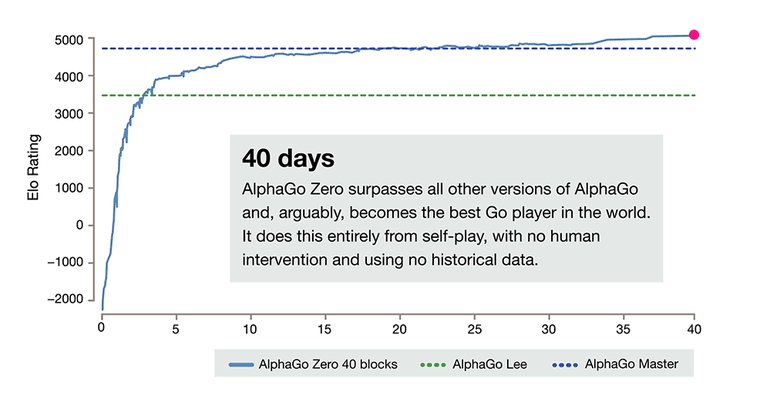

```python
display(Markdown("## DeepMind zbudował AlphaZero i AlphaGo do gry w Go - model pokonał mistrza świata!"))
Image("ml_figures/Wstep_alphago_zero_learning_curve.png", width=800, height=600)
```

```python
display(Markdown('## Drony wyprzedzające ludzi w wyścigu - Universitat Zurich 2023'))
YouTubeVideo("fBiataDpGIo&t=3s", width=800, height=600)
# display(vid)
#display.YouTubeVideo(data="https://www.youtube.com/watch?v=fBiataDpGIo&t=3s")
```

Drony wyprzedzające ludzi w wyścigu - Universitat Zurich 2023

[video not shown]

# Problemy uczenia maszynowego i architektury modeli

## Estymacja gęstości

1. dane: N punktów w wielowymiarowej przestrzeni
2. cel: estymacja gęstości prawdopodobieństwa
- **klastrowanie** próba znalezienia struktury danych
- **identyfikacja anomalii** wyszukiwanie obszarów niskiej gestości i ich opis
- **identyfikacja skupisk** umożliwia etykietowanie punktów
3. modele
- histogram
- modele kernelowe
- metody najbliższych sąsiadów

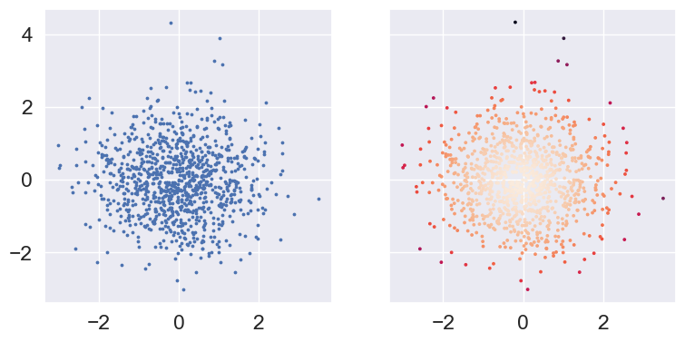

```python
from sklearn.neighbors import KernelDensity
from numpy.random import Generator, PCG64
X = np.random.normal(size=(1000, 2))
kd = KernelDensity()
kd.fit(X)
dens = kd.score_samples(X)
# plt.subplot(2, 1, 1)
# plt.scatter(X[:, 0], X[:, 1], s=3.)
# plt.subplot(2, 1, 2)
# plt.scatter(X[:, 0], X[:, 1], s=3., c=dens)

# plt.scatter(X[:, 0], X[:, 1], s=3.)
# plt.scatter(X[:, 0], X[:, 1], s=5., c=dens)

fig, axs = plt.subplots(1, 2, sharey="row", figsize=(8, 4))
axs[0].scatter(X[:, 0], X[:, 1], s=3.)
axs[1].scatter(X[:, 0], X[:, 1], s=3., c=dens)
plt.show()
```

## Redukcja wymiarowości

1. **Przekleństwo wymiarowości**
- dane: N przykładów, każdy wektorem o wymiarze D w hipersześcianie $[0, 1]^D$
- rozkład równomierny:
  - jaki procent przykładów będzie odległy od początku układu **co najwyżej** o 0.5 w każdym kierunku?

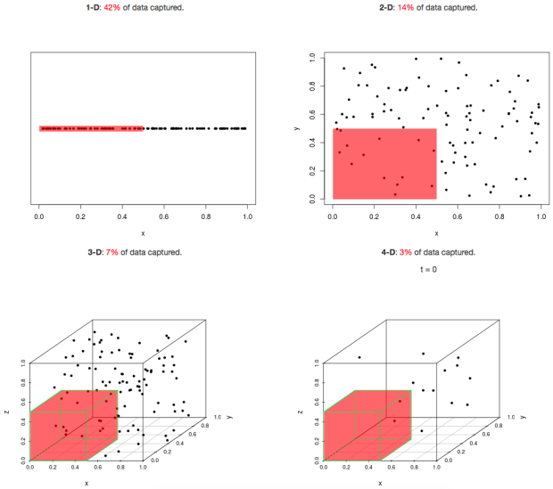

```python
Image("ml_figures/Wstep_COD.png", width=600, height=600)
```

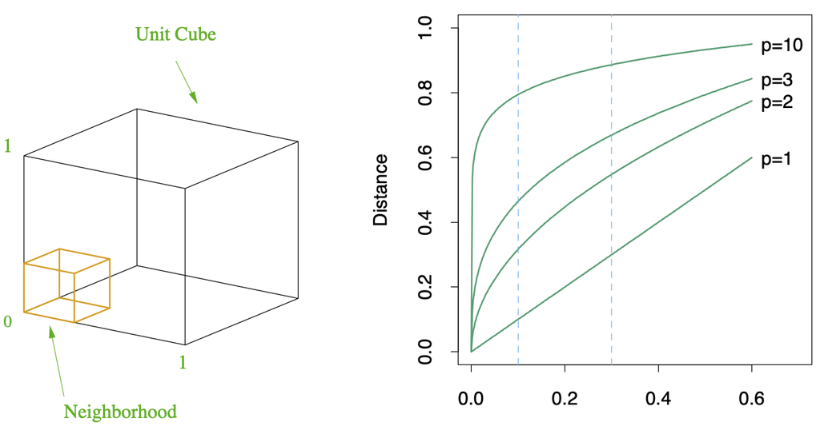

```python
Image("ml_figures/fraction.png", width=600, height=600)
```

- jaka jest szansa, że dowolny punkt leży w odległosci co najwyżej 1 od środka układu współrzędnych?
  - dla $D=2$ mamy $$\pi r^2/(2r)^2 \simeq 0.785$$
  - dla $D=3$ mamy $$(4/3)\pi r^3 / (2r)^3 \simeq 0.523$$
- ten współczynnik bardzo szybko maleje
  - punkty danych stają się coraz bardziej od siebie odległe
- uczenie maszynowe polega na znajdywaniu *podobieństw*
  - punkty odległe od siebie są coraz mniej "podobne"
  - wraz ze wzrostem $D$ będzie potrzeba coraz większego N punktów - wzrost jest **wykładniczy**
  - wraz ze wzrostem coraz większa frakcja przestrzeni będzie potrzebna dla znalezienia takiej samej frakcji przykładów

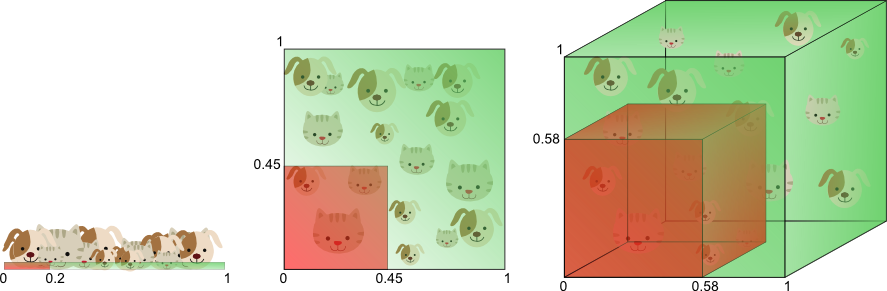

```python
Image("ml_figures/Wstep_curseofdimensionality.png", width=800, height=600)
```

- zwykle cechy danych są ze sobą skorelowane
- wiele cech (ang. features) **nie ma** wpływu na poszukiwane wartości
- potrzebna jest redukcja wymiarowości
  - zmniejszy wymagane minimalne N
  - usunięcie skorelowanych i nieistotnych cech
  - niektóre cechy są kombinacjami liniowymi innych
2. narzędzia
- Principal Component Analysis PCA
- Independent Component Analysis ICA
- manifold learning

###### Klasyfikacja

1. **dane** $$\{(x_i, y_i),i=1,\dots,N\}$$ przy czym $$y_i\in\{1,\dots,K\}$$ który jest zbiorem **możliwych** klas
2. **cel** model przewidujący poprawną odpowiedź z najmniejszym oczekiwanym błędem
- interesuje nas błąd na zbiorze przykładów, których algorytm budujący model **nie** widział

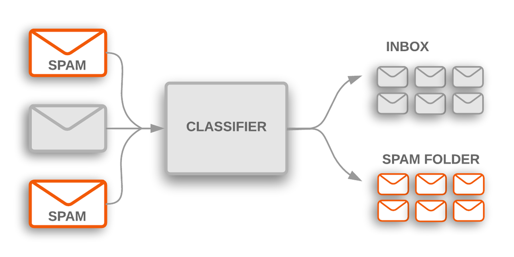

  [Google]
3. **rodzaje modeli klasyfikacji**
- binarna (binary): dwie dostępne klasy (dobry/niedobry), (spam/normalny), (należący do klasy/inny)
- wieloklasowa (multi-class): prawdziwa *dokładnie* jedna z K możliwych klas (koza **albo** małpa **albo** krowa **albo** ryba)
- wielo-etykietowa (multilabel): gdy przykład może być zaklasyfikowany do *kilku* możliwych klas, ale nie w hierarchii
  - klasyfikacja artykułów w gazecie (sport / polityka / miejskie / zagranica / społeczne)
    - bardzo trudne, słabo rozwinięte
3. **modele**
- liniowe / nieliniowe

[figure not shown]

  [Wiki]
  - modele liniowe budują **hiperpłaszczyzny** rozdzielające w przestrzeni cech
  - użyte cechy wejściowe mogą być nielinowymi funkcjami atrybutów z danych
- klasyfikator Bayesowski i naiwny klasyfikator Bayesowski
- regresja logistyczna
- metody dyskryminacyjne
- klasyfikacja z wykorzystaniem metod najbliższych sąsiadów
- Support Vector Machines SVM

[figure not shown]

- drzewa decyzyjne i lasy drzew

[figure not shown]

- drzewa gradient boosted
- modele składające wyniki, np. AdaBoost
- sieci neuronowe
- modele rekurencyjne

[figure not shown]

  - analiza tekstu NLP
4. **problemy**
- w jaki sposób ocenić czy znaleziony model jest *dobry*?
  - dodatkowe zbiory danych, porównywanie z rzeczywistością
  - walidacja krzyżowa czy metody bootstrap dla maksymalnego wykorzystania dostępnych danych jednocześnie do uczenia jak i walidacji (testowania) modeli
- pojemność modeli
  - model o dużej liczbie parametrów będzie potrafił *zapamiętać* dane uczące **ale** będzie słabo przewidywał
  - optimum: znaleźć najmniejszy model, który daje wystarczająco dobrą dokładność
- w jaki sposób porównywać między sobą modele?
  - testy statystyczne pozwalające porównywać modele
  - wizualizacja wyników
    - [Popularność Trumpa w USA](https://projects.fivethirtyeight.com/trump-approval-ratings/?ex_cid=rrpromo).
    - pakiety `pandas`, `matplotlib`, `seaborn`, `bokeh` w Pythonie (miedzy innymi)
    - jak robią to w [fivethirtyeight.com 2016](https://fivethirtyeight.com/features/the-52-best-and-weirdest-charts-we-made-in-2016/) w 2016, a jak w [fivethirtyeight.com 2022](https://fivethirtyeight.com/features/best-charts-2022/) w 2022?

## Analiza szeregów czasowych

1. **dane** $$(t_1, y_1), (t_2, y_2), \dots, (t_N, y_N)$$
2. **cel** przewidzenie $y_{k+1}$ na podstawie $$(t_{k-p},y_{p}),\dots,(t_k,y_k)$$
- celem może być zarówno regresja jak i klasyfikacja

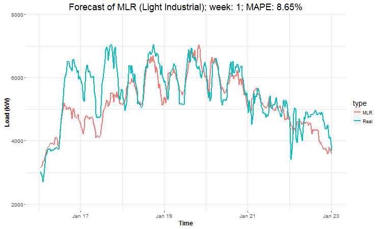

[tutaj wielokrotna regresja liniowa, MAPE - mean average percentage error, źródło: rweekly]

3. **problemy**
- wartość $y_k$ zależy bezpośrednio od poprzednich (inaczej niż w regresji)
- wiele danych jest szumem
- w danych występują trendy i okresowości
  - zużycie prądu ulega fluktuacjom dziennym, tygodniowym, rocznym
  - cały czas rośnie
- problem szerokości okienka
  - zanikanie wpływu starych danych, ale istnienie wpływu pamięci długoterminowej
4. **modele**
- ARMA: auto-regressing moving average $$x_t=\mu+\epsilon_t+\sum_{i=1}^pw_i\epsilon_{t-i}$$
  - przewidywanie na podstawie ostatniego okienka o szerokości $p$
- analiza fourierowska i falkowa
- sieci neuronowe

# Pipeline uczenia

- typowy przebieg procesu uczenia

[figure not shown]

  [Google]
  - zbieranie danych
  - wyszukiwanie podstawowych własności problemu: ile jest klas, ile przykładów, jakie są atrybuty, czy klasy są niezależne, etc.
    - gdy są to szeregi czasowe, to określić orientacyjną zależność od poprzednich wartości?
    - określić rozkład liczności klas w przykładach
      - jeśli są bardzo nierównoliczne, trzeba będzie jakoś dostosować model/dane
  - przygotowanie danych
    - reprezentacja atrybutów, liczba atrybutów, ewentualna redukcja wymiarowości
  - budowa modelu
    - wybór architektury (wielu różnych) w zależności od problemu
  - trenowanie i ewaluacja modeli
    - wybór funkcji kosztu
      - **accuracy** czyli frakcja poprawnych klasyfikacji

# Źródła danych i konkursy

- ogólnie dostępne źródła danych są potrzebne dla wiarygodnego porównywania tworzonych algorytmów
  - [UCI Machine Learning Repository](https://archive.ics.uci.edu/ml/index.php)
- niektóre serwisy dzielą się swoimi danymi
  - szanse demokratów i republikanów na przejęcie [kontroli nad izbą reprezentantów])https://projects.fivethirtyeight.com/2018-midterm-election-forecast/house/?ex_cid=rrpromo)
  - fivethirtyeight.com (często także kod i źródła dla wizualizacji)
  - MNIST: ręcznie pisane cyfry 28x28 w skali szarości 60 tysięcy przykładów uczących i 10 tysięcy wybranych testowych
    - wszystkie wyniki są testowane na tych samych przykładach
  - [CIFAR-10/CIFAR-100](http://www.cs.toronto.edu/~kriz/cifar.html): obrazy kolorowe 32x32 z 10 lub 100 klas
    - 60 tysiecy etykietowanych, 10 tysiecy testowych
    - dostępne znacznie więcej nie etykietowanych (kilkadziesiąt milionów)
    - [COCO](http://cocodataset.org/#home) Common Objects in COntext
      - wiele obiektów na tym samym obrazie
      - 330 tysięcy dostępnych, ponad 200 etykietowanych (każdy obiekt na obrazie)
      - MS-COCO jest corocznym konkursem polegajacym na rozdzielaniu obiektów na filmie
      - obiekty są **w różnej** skali
    - [CelebA](http://mmlab.ie.cuhk.edu.hk/projects/CelebA.html) obrazy twarzy 32 x 32; bardzo często wykorzystywany w testach modeli generatywnych
    - [ImageNet](http://image-net.org/index) ponad 14 milionów zdjęć różnych obiektów
      - ułożonych w hierarchię według WordNet
      - coroczny konkurs na Kaggle
      - w 2012 wygrał go Alex Krizevsky z konwolucyjną architekturą AlexNet
- jest wiele konkursów polegajacych na rozwiązaniu problemu
  - [Kaggle](https://www.kaggle.com/?)